# Predicting next based on current feature values

## Structure

Predictors:

- Valence of track $i$
- Energy of track $i$
- Loudness of track $i$
- Tempo of track $i$
- Track number of $i$ (1 to 16)

Dependent variable:

- Valence/energy/loudness/tempo of track $i+1$

## Model 1 - Splines regression

Overall, we can explain only a small ammount of variance from our data. All models are significant, and the coefficients of all variables of interest are significant. Only some interactions are significant. I didn't look deep for effects of different variables because of the very low R2.

Only thing I find interesting here is the fact that tempo has the lowest R2, which is consistent with what we found [here](https://pasoneto.github.io/doc_suomi/presentations/slides/descriptives.slides.html#/3) (small difference in tempo between positions).

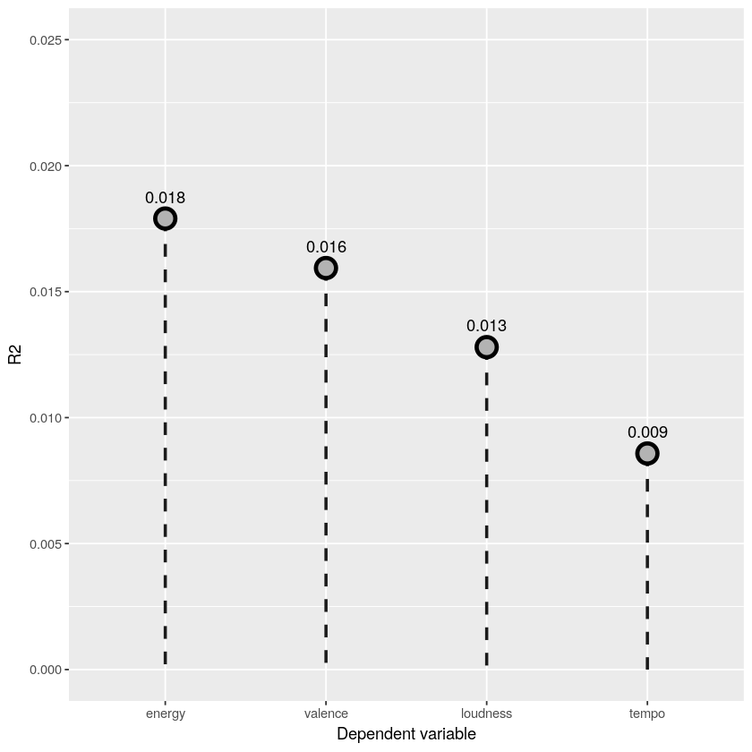

```r
lr = data.frame(feature = c("valence", "energy", "loudness", "tempo"),
                R2 = c(valence_spline$adj.r.squared, energy_spline$adj.r.squared, loudness_spline$adj.r.squared,tempo_spline$adj.r.squared))

# lr %>% ggplot(aes(x = reorder(feature, -R2), y = R2)) + geom_bar(stat = "identity") +
#        geom_text(aes(label = R2), vjust = -1.5)
lr %>%
    ggplot(aes(x = reorder(feature, -R2), y = R2)) +
    geom_segment(aes(xend = feature, yend = 0), size = 1, lineend = "butt", linetype = "dashed", col = "gray10") +
    geom_point(size = 5, shape = 21, colour = "black", fill = "gray70", stroke = 2) +
    geom_text(aes(label = round(R2, digits = 3)), vjust = -1.25)+ylim(c(0, 0.025)) +
    xlab("Dependent variable")+ylab("R2")
```

## Model 2 - Random forest

Here I'm feeding the same set of predictors and dependent variables to a random forest regressor.

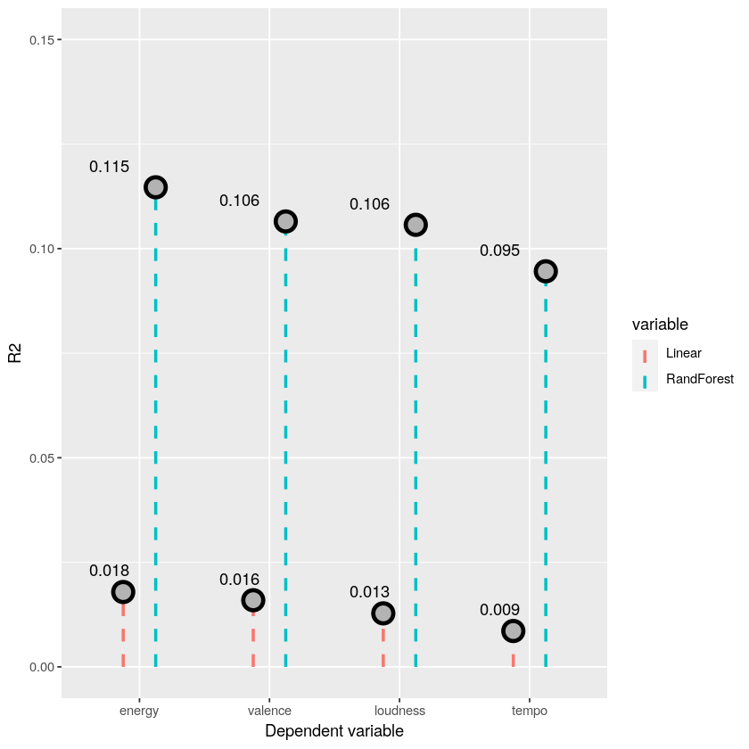

```r
options(digits=2)
colnames(lr) = c("Features", "Linear", "RandForest")

lr %>% melt(id.vars = "Features", measure.vars = c("Linear", "RandForest")) %>%
    ggplot(aes(x = reorder(Features, -value), y = value, color = variable, group = variable))+
         geom_linerange(aes(ymin = 0, ymax = value, yend = 0), size = 1, lineend = "butt", linetype = "dashed", position=position_dodge(width = .5)) +
         geom_point(size = 5, shape = 21, colour = "black", fill = "gray70", stroke = 2, position=position_dodge(width = .5)) +
         geom_text(colour = "black", aes(label = round(value, digits = 3)), hjust = 1.25, vjust = -1.25)+ylim(c(0, 0.15)) +
         xlab("Dependent variable")+ylab("R2")
```

### Feature imporance

This metrics represents the % of increase in $MSE$ as a given predictor variable is randomly permutated.

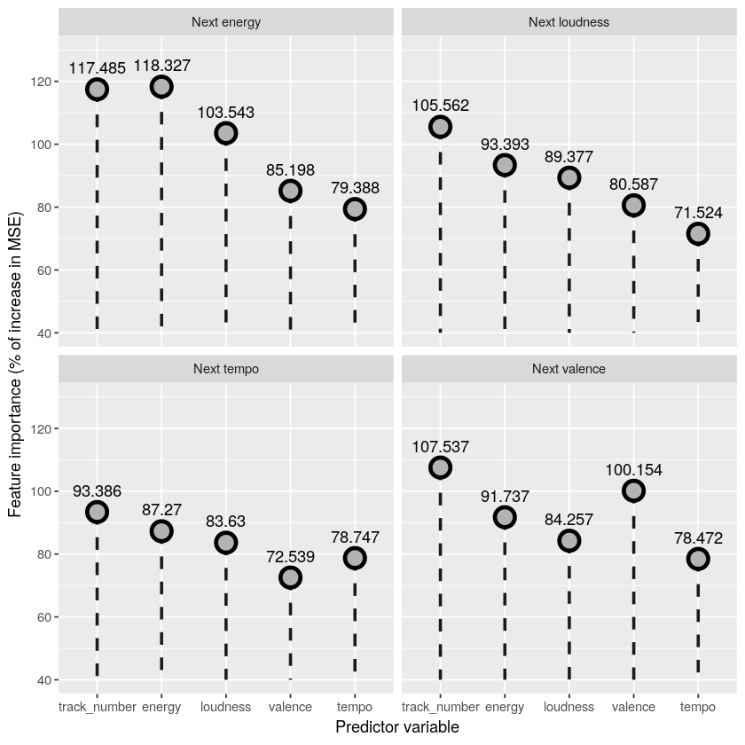

```r
rf_imp = data.frame(feature_importance = c(data.frame(importance(valence))$X.IncMSE, data.frame(importance(energy))$X.IncMSE, data.frame(importance(loudness))$X.IncMSE, data.frame(importance(tempo))$X.IncMSE),
                variable = c(rownames(data.frame(valence$importance)), rownames(data.frame(energy$importance)), rownames(data.frame(loudness$importance)), rownames(data.frame(tempo$importance))),
                predicted = c(rep("Next valence", 5), rep("Next energy", 5), rep("Next loudness", 5), rep("Next tempo", 5)))
rf_imp %>%
    ggplot(aes(x = reorder(variable, -feature_importance), y = feature_importance)) +
    facet_wrap(~predicted)+
    geom_segment(aes(xend = variable, yend = 40), size = 1, lineend = "butt", linetype = "dashed", col = "gray10") +
    geom_point(size = 5, shape = 21, colour = "black", fill = "gray70", stroke = 2) +
    geom_text(aes(label = round(feature_importance, digits = 3)), vjust = -1.25)+ylim(c(40, 130)) +
    xlab("Predictor variable")+ylab("Feature importance (% of increase in MSE)")
```

## Model comparison - test dataset

Now I'll do a cross validation of these models and evaluate their performance in terms of RMSE. In case Random Forest is not overfitting, we should see a lower RMSE for it, since its R2 was 10 times higher than the R2 of the splines regression (~0.01 agains ~0.1)

## Result

In fact, RMSE is lower when we use the Random Forest. The values below correspond to 10 runs on different train/test splits of the data. RMSE is the mean RMSE of these runs, and the x axis represents the variable that is being predicted.

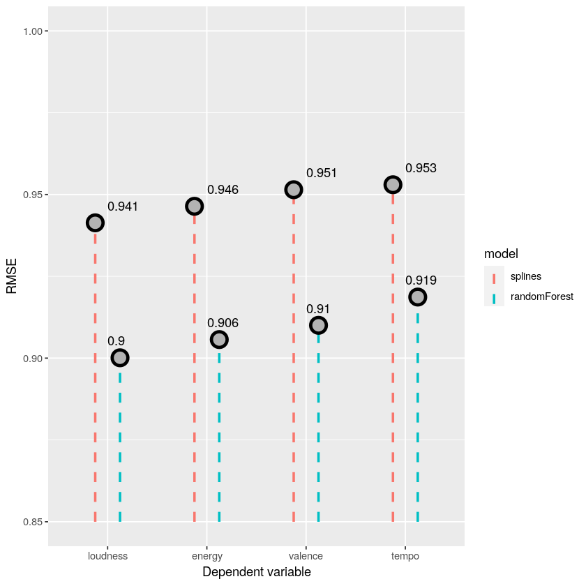

```r
overall = dplyr::bind_rows(splines_rmse, rf_rmse)
overall %>%
    ggplot(aes(x = reorder(dependent_variable, rmse), y = rmse, color = model, group = model))+
    geom_linerange(aes(ymin = 0.85, ymax = rmse), size = 1, linetype = "dashed", position=position_dodge(width = .5)) +
    geom_point(size = 5, shape = 21, colour = "black", fill = "gray70", stroke = 2, position=position_dodge(width = .5)) +
    geom_text(colour = "black", aes(label = round(rmse, digits = 3)), hjust = 0, vjust = -1.25)+ylim(c(0.85, 1)) +
    xlab("Dependent variable")+ylab("RMSE")
```

## Discussion

However, this worries me for the following reason:

### Problem

The question that we're asking here is: "can we predict the feature of track $i+1$ given the feature(s) of track $i$?

If we look at the pre-normalized distribution of say, loudness, we could hypothesize that, given an observed track (blue line), the loudness of the next track would, most likely, be higher (e.g. red line). After z-score transformation, the distribution gets less skewed, and more like a gaussian curve. Still, this problem would remain.

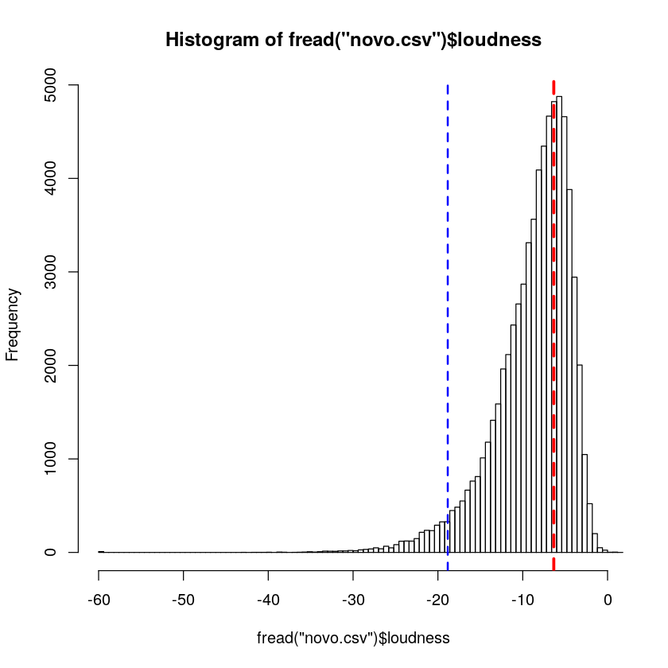

```r
hist(fread("novo.csv")$loudness, xlim=c(-60, 0), breaks = seq(-60, 2, 0.6), )
abline(v = mean(fread("novo.csv")$loudness)+2.5, col="red", lwd=3, lty=2)
abline(v = mean(fread("novo.csv")$loudness)-10, col="blue", lwd=2, lty=2)
```

So I'm wondering: given a normalized valence level, a non linear model, such as splines, should be able to predict, to some extent, the valence of the next track, simply due to the probability density function.

My point: If we use the current feature to predict the next feature, we might be asking the wrong question, since values at the extreme of the distribution will most lileky be followed by more probable values (a kind of regression towards the mean effect).

I'm not absolutely sure about what I just said, but perheps you can help me see whether my worry makes sense or not.

### My case for classification

In fact, if we try to categorize the position of a track, we're not explicitly looking for sequential effects. We are, however, trying to fit tracks into categories that correspont to a certain position in time (i.e. 1st, 2nd, 3d and 4th parts of the album).